# Adult_Salary_Predict (P1)

An individual’s annual income results from various factors. Intuitively, it is influenced by the individual’s education level, age, gender, and occupation etc.

This is a widely cited dataset. I choosed this project to run two different ML alghoritms plus trying some feature engineering and at the end compareing the results within eachother.  
I wish to share it here because it is a good starter example for data pre-processing and machine learning practices.

**Fields**

We can explore the possibility in predicting income level based on the individual’s personal information.

Acknowledgements This dataset named “adult” is found in the UCI machine learning repository http://www.cs.toronto.edu/~delve/data/adult/desc.html

The detailed description on the dataset can be found in the original UCI documentation http://www.cs.toronto.edu/~delve/data/adult/adultDetail.html

Imported packages and assigned our dataset into a dataframe.

```python
import pandas as pd
from sklearn.preprocessing import LabelEncoder
from sklearn.model_selection import train_test_split
from sklearn import preprocessing
import sklearn.model_selection as ms
from sklearn import linear_model
import sklearn.metrics as sklm
import numpy as np
import numpy.random as nr
import matplotlib.pyplot as plt
import seaborn as sns
import scipy.stats as ss
import matplotlib.pyplot as plts
from scipy.stats import pearsonr, spearmanr

import sklearn.decomposition as skde

%matplotlib inline
```

```python
df =  pd.read_csv('adult.csv', sep=','  , engine='python')
```

now lets observe our dataset to findout:

- whats the dataframe shape.
- whats the number of rows.
- whats the number of columns(Features).
- Whats the number of duplicates without targeting any subset.

```python
# Printing number of observations, variables including the target, and duplicate samples
print(f"\nDataFrame Shape :", df.shape)
print(f"Number of rows: .............. {df.shape[0]}") # Number of observations (number of rows)
print(f"Number of Freatures: ............ {df.shape[1]} incl. target") # Number of variables or attributes ( number of columns)
print(f"Number of duplicate entries: .... {df.duplicated().sum()}")
```

```
DataFrame Shape : (32561, 15)
Number of rows: .............. 32561
Number of Freatures: ............ 15 incl. target
Number of duplicate entries: .... 24
```

once we take a look on our feautures,

1. age
2. workclass
3. education
4. sex
5. ..
- we see there is no unique feauture or reliable subset such as customer ID that we can rely to to delete duplicates based on it, therefore I cant detect true duplicates which has same information in each every column cell.
- which means we should go for the second step on our data observation and pre-processing without deleting duplicates.

### Converting the target from binary/categoric into binary/n

```python
# Converting the target from binary/categoric into binary/n
le = LabelEncoder()
df['target_encoded'] = le.fit_transform(df['target'])
print(df['target_encoded'])
```

```
0        0
1        0
2        0
3        0
4        0
        ..
32556    0
32557    1
32558    0
32559    0
32560    1
Name: target_encoded, Length: 32561, dtype: int32
```

divinding categorical from numerical is always recommended so we can get better report on our data set to distinct our dataset and to know which variable has variance and which does not have.

```python
num_vars = df.columns[df.dtypes !='object']
cat_vars = df.columns[df.dtypes == 'object']
```

one of the other step in our data pre-proicessing is to find nulls and check how many nulls do we have.

```python
df[num_vars].isnull().sum()
```

```
age               0
fnlwgt            0
education-num     0
capitl-gain       0
capital-loss      0
hour-per-week     0
target_encoded    0
dtype: int64
```

```python
df[cat_vars].isnull().sum()
```

```
workclass         0
education         0
marital-status    0
occupation        0
relationship      0
race              0
sex               0
native-country    0
target            0
dtype: int64
```

- nulls: nulls are the total absence of values or unknown info and based on quantities we can decided to what to do with it next. such as deleting the whole column or replacing .This all depends on if we have nulls and if we have we should know how many they are but because here our dataset has no nulls so we can pass this part to the next.

### General stats of all feautures

```python
df.head()
```

|  | age | workclass | fnlwgt | education | education-num | marital-status | occupation | relationship | race | sex | capitl-gain | capital-loss | hour-per-week | native-country | target | target_encoded |
| --- | --- | --- | --- | --- | --- | --- | --- | --- | --- | --- | --- | --- | --- | --- | --- | --- |
| 0 | 39 | State-gov | 77516 | Bachelors | 13 | Never-married | Adm-clerical | Not-in-family | White | Male | 2174 | 0 | 40 | United-States | <=50K | 0 |
| 1 | 50 | Self-emp-not-inc | 83311 | Bachelors | 13 | Married-civ-spouse | Exec-managerial | Husband | White | Male | 0 | 0 | 13 | United-States | <=50K | 0 |
| 2 | 38 | Private | 215646 | HS-grad | 9 | Divorced | Handlers-cleaners | Not-in-family | White | Male | 0 | 0 | 40 | United-States | <=50K | 0 |
| 3 | 53 | Private | 234721 | 11th | 7 | Married-civ-spouse | Handlers-cleaners | Husband | Black | Male | 0 | 0 | 40 | United-States | <=50K | 0 |
| 4 | 28 | Private | 338409 | Bachelors | 13 | Married-civ-spouse | Prof-specialty | Wife | Black | Female | 0 | 0 | 40 | Cuba | <=50K | 0 |

### General stats of numerical variables

```python
describe = df.describe()
describe.append(pd.Series(df.var(), name='variance'))
```

|  | age | fnlwgt | education-num | capitl-gain | capital-loss | hour-per-week | target_encoded |
| --- | --- | --- | --- | --- | --- | --- | --- |
| count | 32561.000000 | 3.256100e+04 | 32561.000000 | 3.256100e+04 | 32561.000000 | 32561.000000 | 32561.000000 |
| mean | 38.581647 | 1.897784e+05 | 10.080679 | 1.077649e+03 | 87.303830 | 40.437456 | 0.240810 |
| std | 13.640433 | 1.055500e+05 | 2.572720 | 7.385292e+03 | 402.960219 | 12.347429 | 0.427581 |
| min | 17.000000 | 1.228500e+04 | 1.000000 | 0.000000e+00 | 0.000000 | 1.000000 | 0.000000 |
| 25% | 28.000000 | 1.178270e+05 | 9.000000 | 0.000000e+00 | 0.000000 | 40.000000 | 0.000000 |
| 50% | 37.000000 | 1.783560e+05 | 10.000000 | 0.000000e+00 | 0.000000 | 40.000000 | 0.000000 |
| 75% | 48.000000 | 2.370510e+05 | 12.000000 | 0.000000e+00 | 0.000000 | 45.000000 | 0.000000 |
| max | 90.000000 | 1.484705e+06 | 16.000000 | 9.999900e+04 | 4356.000000 | 99.000000 | 1.000000 |
| variance | 186.061400 | 1.114080e+10 | 6.618890 | 5.454254e+07 | 162376.937814 | 152.458995 | 0.182826 |

The benefit of this chart is we can see quartiles as well as variance, so we can determine which ones are pretty low variance and this might be completely useless.

### General stats of categorical variables

```python
df.describe(include=[object])
```

|  | workclass | education | marital-status | occupation | relationship | race | sex | native-country | target |
| --- | --- | --- | --- | --- | --- | --- | --- | --- | --- |
| count | 32561 | 32561 | 32561 | 32561 | 32561 | 32561 | 32561 | 32561 | 32561 |
| unique | 9 | 16 | 7 | 15 | 6 | 5 | 2 | 42 | 2 |
| top | Private | HS-grad | Married-civ-spouse | Prof-specialty | Husband | White | Male | United-States | <=50K |
| freq | 22696 | 10501 | 14976 | 4140 | 13193 | 27816 | 21790 | 29170 | 24720 |

The other case we need to check is our missing values, they are similar to null values but might be filled in numbers such 999 or ?, or anything I discovered that missing value at this dataset is presented as ?. So lets do check how many missing values we have per the count of total rows so we can see how big or small they are.

```python
for col in df.columns:
    if df[col].dtype == object:
        count = 0
        count = [count + 1 for x in df[col] if x == ' ?']
        print(col + ' ' + str(sum(count)* 100 / len(df)))
```

```
workclass 5.638647461687294
education 0.0
marital-status 0.0
occupation 5.660145572924664
relationship 0.0
race 0.0
sex 0.0
native-country 1.7904855501980896
target 0.0
```

So we see that we have about 5.6 percent missing values at workclass also the same portion at occupation and near 2 percent at native-country.

- what is interesting is occupation and workclass has very close amount of missing values, which means there could be a pattern that aim us to find the real value of missing values. Since the missing values are very small in portion so its not recommended to delete it all but also replacing value strategy has its consequences which leads us to have a biased dataset.

Another test to see if we have missing values, but it contain all the variables such as categorical and numerical

```python
#(df.astype(np.object) == " ?").any()
```

[output not shown]

As you see there is no missing value in our numerical variables.

### Visualization of Pearson-correlations (heatmap)

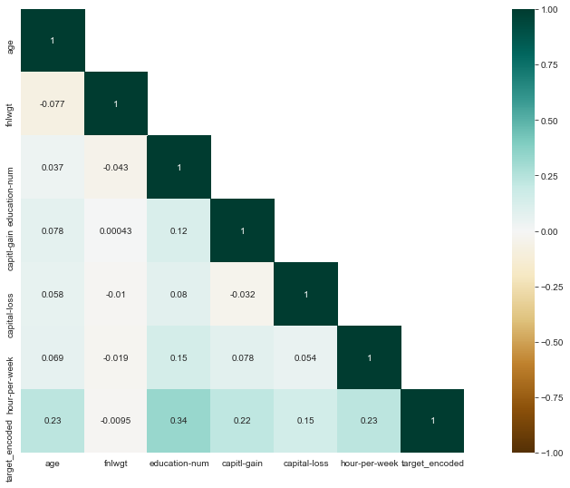

```python
mask = np.triu(df.corr(), 1)
plt.figure(figsize=(19, 9))
sns.heatmap(df.corr(), annot=True, vmax=1, vmin = -1, square=True, cmap='BrBG', mask=mask);
```

Pearson correlation is one of the ways to find linear relationship betwean variables and as well as the target variable. but as you see we can just see variables that does have variance or in otherword numerical variables.

### whisker box Visualization to show comparison betwean numerical variables vs target

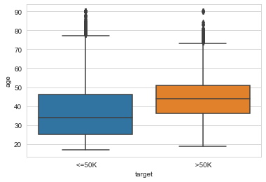

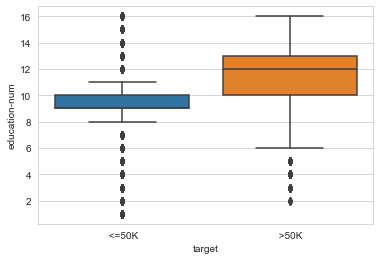

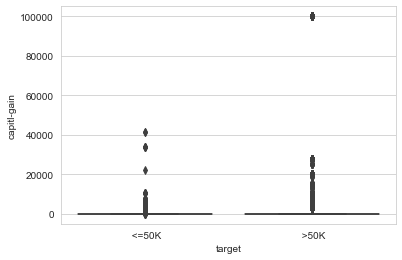

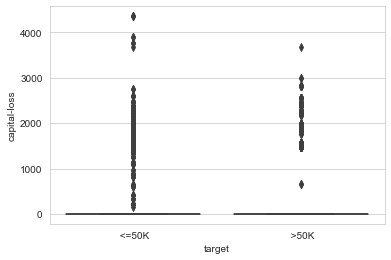

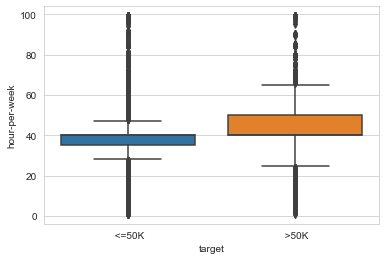

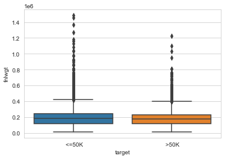

```python
def plot_box(credit, cols, col_x = 'target'):
    for col in cols:
        sns.set_style("whitegrid")
        sns.boxplot(col_x, col, data=credit)
        plt.xlabel(col_x) # Set text for the x axis
        plt.ylabel(col)# Set text for y axis
        plt.show()

num_cols = ['age', 'education-num', 'capitl-gain',
            'capital-loss', 'hour-per-week','fnlwgt']
plot_box(df, num_cols)
```

### Data visualization using seaborn.

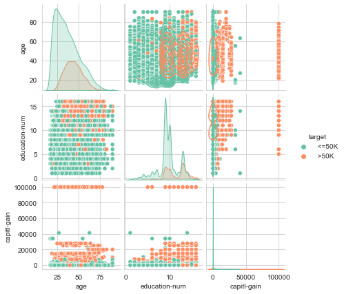

```python
num1_cols = ['age', 'education-num', 'capitl-gain','target']
sns.pairplot(df[num1_cols], hue='target', palette="Set2", diag_kind="kde", size=2).map_upper(sns.kdeplot, cmap="Blues_d")
```

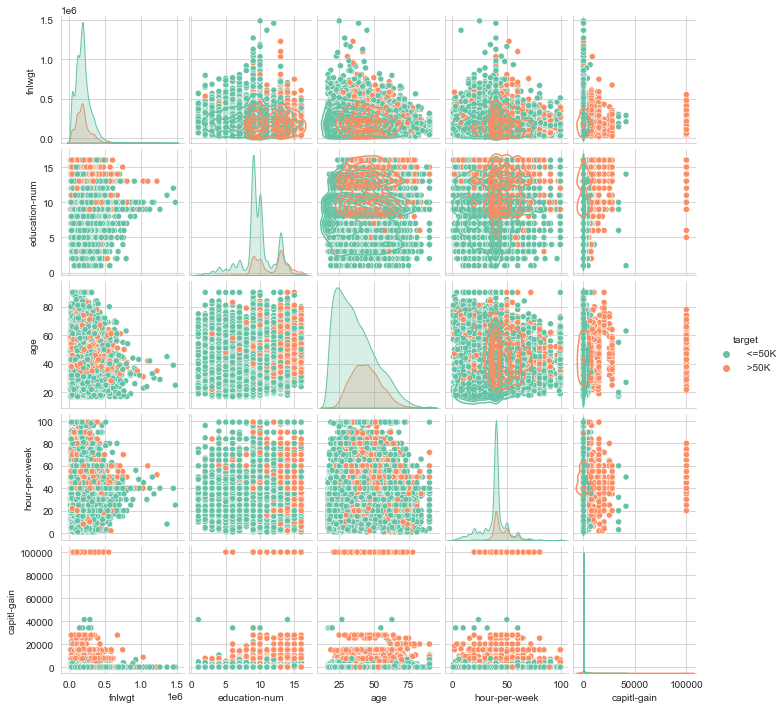

```python
num2_cols = ['fnlwgt','education-num','age','hour-per-week','capitl-gain','target']
sns.pairplot(df[num2_cols], hue='target', palette="Set2", diag_kind="kde", size=2).map_upper(sns.kdeplot, cmap="Blues_d")
```

As we see we can have composition of our target datas plus distribution, the other thing is I can see loads of >50k in third quartile of capital-gain. Now I might doubted to just delete it immediatley, because it might be very useful for our progress to determine a classifier.

### scatter plot visualization

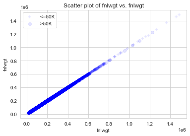

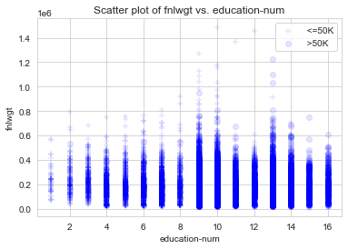

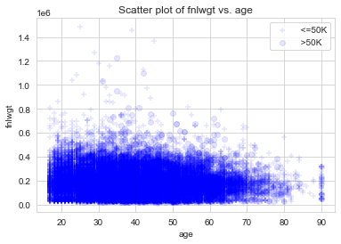

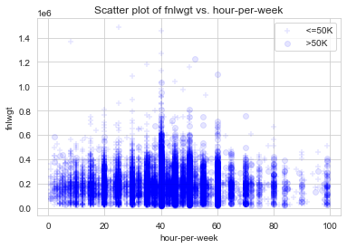

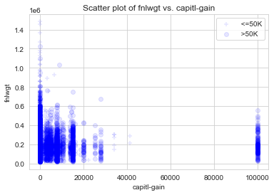

```python
def plot_scatter_shape(df, cols, shape_col = 'target', col_y = 'fnlwgt', alpha = 0.1):
    shapes = ['+', 'o'] # pick distinctive shapes
    unique_cats = df[shape_col].unique()
    for col in cols: # loop over the columns to plot
        sns.set_style("whitegrid")
        for i, cat in enumerate(unique_cats): # loop over the unique categories
            temp = df[df[shape_col] == cat]
            sns.regplot(col, col_y, data=temp, marker = shapes[i], label = cat,
                        scatter_kws={"alpha":alpha}, fit_reg = False, color = 'blue')
        plt.title('Scatter plot of ' + col_y + ' vs. ' + col) # Give the plot a main title
        plt.xlabel(col) # Set text for the x axis
        plt.ylabel(col_y)# Set text for y axis
        plt.legend()
        plt.show()

num3_cols = ['fnlwgt','education-num','age','hour-per-week','capitl-gain']
plot_scatter_shape(df, num3_cols)
```

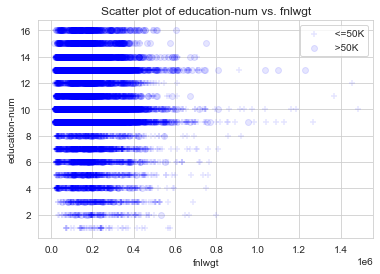

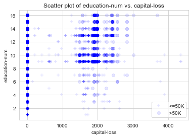

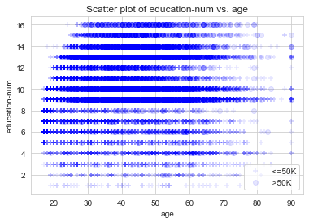

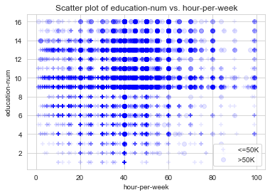

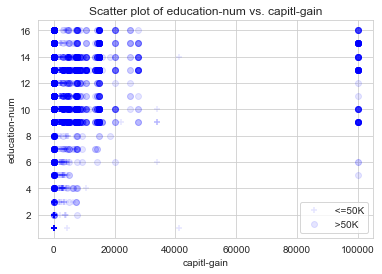

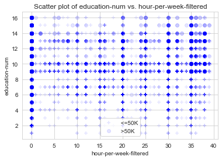

```python
def plot_scatter_shape(df, cols, shape_col = 'target', col_y = 'education-num', alpha = 0.1):
    shapes = ['+', 'o'] # pick distinctive shapes
    unique_cats = df[shape_col].unique()
    for col in cols: # loop over the columns to plot
        sns.set_style("whitegrid")
        for i, cat in enumerate(unique_cats): # loop over the unique categories
            temp = df[df[shape_col] == cat]
            sns.regplot(col, col_y, data=temp, marker = shapes[i], label = cat,
                        scatter_kws={"alpha":alpha}, fit_reg = False, color = 'blue')
        plt.title('Scatter plot of ' + col_y + ' vs. ' + col) # Give the plot a main title
        plt.xlabel(col) # Set text for the x axis
        plt.ylabel(col_y)# Set text for y axis
        plt.legend()
        plt.show()

num3_cols = ['fnlwgt','capital-loss','age','hour-per-week','capitl-gain','hour-per-week-filtered']

plot_scatter_shape(df, num3_cols)
```

Now since we have just investigated on our numerical variables lets get to our categorical variables and see what we have there.

```python
df.head()
```

[output not shown]

```python
bins = [0,20,40,100]
labels = ['0-20','20-40','41+']
df['hour-per-week-cat'] = pd.cut(df['hour-per-week'], bins, labels = labels,include_lowest = True)
```

```python
bins = [0,500,8500,20000]
labels = ['0-500','501-8500','10k+']

df['capital-gain1'] = pd.cut(df['capitl-gain'], bins, labels = labels,include_lowest = True)

print(df['capital-gain1'])
```

```
0        501-8500
1           0-500
2           0-500
3           0-500
4           0-500
           ...
32556       0-500
32557       0-500
32558       0-500
32559       0-500
32560        10k+
Name: capital-gain1, Length: 32561, dtype: category
Categories (3, object): ['0-500' < '501-8500' < '10k+']
```

### Violin visualization (numerical variables)

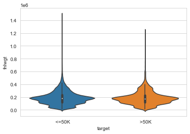

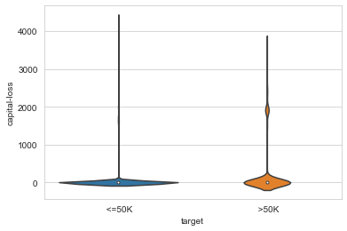

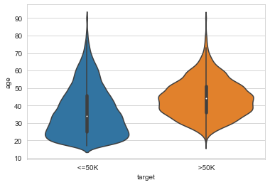

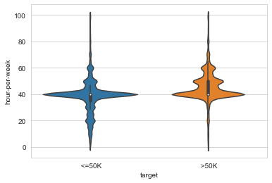

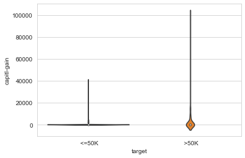

```python
num_cols = ['fnlwgt','capital-loss','age','hour-per-week','capitl-gain']


def plot_violin(df, cols, col_x = 'target'):
    for col in cols:
        sns.set_style("whitegrid")
        sns.violinplot(col_x, col, data=df)
        plt.xlabel(col_x) # Set text for the x axis
        plt.ylabel(col)# Set text for y axis
        plt.show()

plot_violin(df, num_cols)
```

I know, it might look repetetive and look similiar to whisker box, but violin is also a good approach to investigate to our numerical variables.

```python
(df.astype(np.object) == " ?").any()
```

[output not shown]

## pearson method for all type of variables

```python
df.apply(lambda x : pd.factorize(x)[0]).corr(method='pearson', min_periods=1)
```

[output not shown]

If you're attempting to do feature selection then you could perform a logistic regression with L1 regularization and select features based on the absolute value of their coefficients.

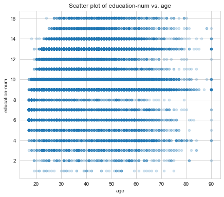

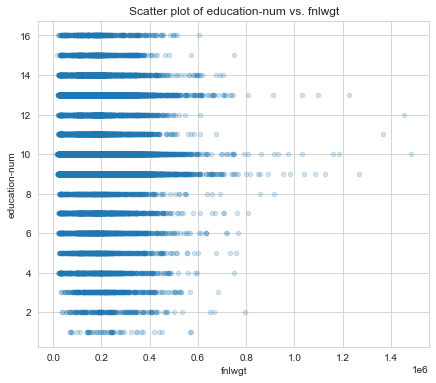

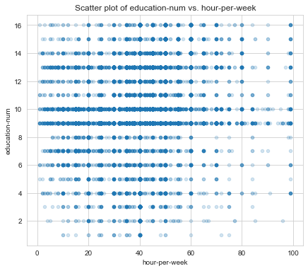

```python
num_cols = [ 'age', 'fnlwgt', 'hour-per-week']


def plot_scatter_t(df, cols, col_y = 'education-num', alpha = 1.0):
    for col in cols:
        fig = plt.figure(figsize=(7,6)) # define plot area
        ax = fig.gca() # define axis
        df.plot.scatter(x = col, y = col_y, ax = ax, alpha = alpha)
        ax.set_title('Scatter plot of ' + col_y + ' vs. ' + col) # Give the plot a main title
        ax.set_xlabel(col) # Set text for the x axis
        ax.set_ylabel(col_y)# Set text for y axis
        plt.show()

plot_scatter_t(df, num_cols, alpha = 0.2)
```